# Human Height Over Time

Author

Austin Mangelson

The Scientific American argues that humans have been getting taller over the years. Is this true? This report is aimed at answering this question.

## Collecting Data

The data for this analysis was retrieved primarily from the World Health Organization and German army conscripts, along with a few other sources which can be found [here](https://byuistats.github.io/M335/maleheight.html).

## Height Analysis

All data tidying and wrangling can be seen here in this code.

```r
new_col_names <-
  as.character(unlist(worldwide_height_estimates[2, ]))

colnames(worldwide_height_estimates) <- new_col_names

tidy_worldwide_height_estimates <-
  worldwide_height_estimates |>
  slice(-c(1, 2)) |>
  pivot_longer(cols = c(`1800`:`2011`),
               names_to = "year",
               values_to = "height",
               values_drop_na = TRUE
  ) |>
  rename(country = `Continent, Region, Country`,
         height_cm = height) |>
  mutate(source = "Tubingen Worldwide Height Data") |>
  mutate(height_in = (height_cm / 2.54)) |>
  relocate(height_in, .after = height_cm) |>
  select(-1)

#--------

tidy_ger_conscripts_19th_century <-
  ger_conscripts_19th_century |>
  select(-1, -5) |>
  rename(year = bdec, height_cm = height) |>
  mutate(
    country = "Germany",
    height_in = (height_cm / 2.54),
    source = "German male conscripts in Bavaria, 19th century") |>
  relocate(country, year, height_cm, height_in, source) |>
  select(-6)

#--------------------

tidy_bav_conscripts_19th_century <-
  bav_conscripts_19th_century |>
  rename(year = bdec, height_cm = height) |>
  mutate(
    country = "Germany",
    height_in = (height_cm / 2.54),
    source = "Bavarian conscripts, 19th century"
  ) |>
  select(-1, -3) |>
  relocate(country, year, height_cm, height_in, source)

#----------------------

tidy_ger_soldiers_18th_century <-
  ger_soldiers_18th_century |>
  select(2, 15) |>
  rename(year = SJ, height_cm = CMETER) |>
  mutate(
    country = "Germany",
    height_in = (height_cm / 2.54),
    source = "German Soldiers 18th Century"
  ) |>
  relocate(country)

#------------------

tidy_BLS_wage_height <-
  BLS_wage_height |>
  select(2) |>
  rename(height_in = height) |>
  mutate(
    country = "United States of America",
    year = "1950",
    height_cm = (height_in * 2.54),
    source = "BLS Wage and Height Data"
  ) |>
  relocate(country, year, height_cm, height_in, source)

#------------------

tidy_heighs1 <-
  heights1 |>
  select(3) |>
  rename(height_in = height) |>
  mutate(
    country = "United States of America",
    year = "1950",
    height_cm = (height_in * 2.54),
    source = "BLS and NLS cross-section"
  ) |>
  relocate(country, year, height_cm, height_in, source)

#----------------

all_height_data <-
  rbind(
    tidy_bav_conscripts_19th_century,
    tidy_BLS_wage_height,
    tidy_ger_conscripts_19th_century,
    tidy_ger_soldiers_18th_century,
    tidy_heighs1,
    tidy_worldwide_height_estimates
  ) |>
  mutate(year = as.numeric(year)) |>
  mutate(
    century = (year %/% 100) + 1,
    decade = (year %/% 10) * 10
  ) |>
  relocate(century, decade, .after = year) |>
  na.omit()
```

First, let’s take a look at how human height has changed worldwide over the years.

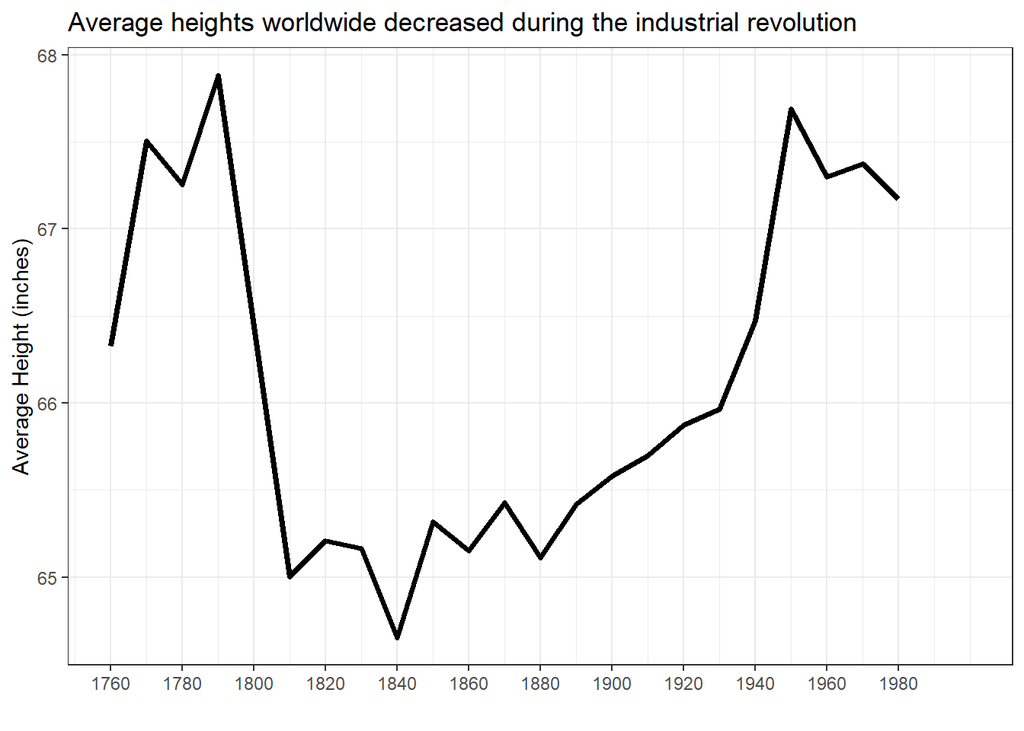

```r
plotting_data <-
  all_height_data |>
  group_by(decade, century) |>
  summarize(mean_height_in = mean(height_in, na.rm = TRUE))

ggplot(plotting_data, aes(x = decade, y = mean_height_in)) +
  geom_line(linewidth = 1.25) +
  scale_x_continuous(breaks = seq(1760, 1980, by = 20)) +
  theme(legend.position = "none") +
  labs(
    title = "Average heights worldwide decreased during the industrial revolution",
  #  subtitle = "Average heights worldwide decreased during the 1800s",
    x = "",
    y = "Average Height (inches)"
  ) +
  theme_bw() +
  theme(legend.position = "none") +
  coord_cartesian(ylim = c(64,71)) +
  coord_cartesian(xlim = c(1760, 2000))
```

As we can see here, the average world height *has* been increasing, but only since the mid 19th century. If we take a look further back, we see that the average human height is returning back to what it used to be over 2 centuries ago.

Let’s take a look at a particularly interesting case study: Germany.

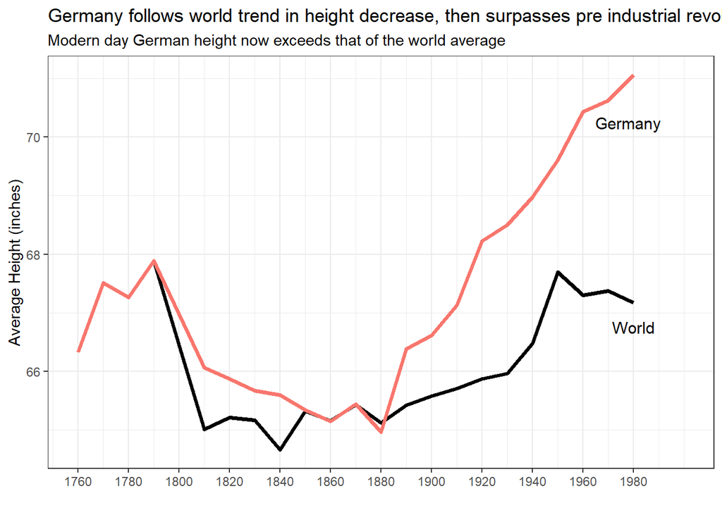

```r
germany_heights <-
  all_height_data |>
  filter(country == "Germany") |>
  group_by(decade) |>
  summarize(mean_height_in = mean(height_in, na.rm = TRUE))

ggplot(plotting_data, aes(x = decade, y = mean_height_in)) +
  geom_line(linewidth = 1.25) +
  scale_x_continuous(breaks = seq(1760, 1980, by = 20)) +
  theme(legend.position = "none") +
  geom_line(data = germany_heights, mapping = aes(x = decade, y = mean_height_in, color = "red"), linewidth = 1.25) +
  labs(
    title = "Germany follows world trend in height decrease, then surpasses pre industrial revolution heights",
    subtitle = "Modern day German height now exceeds that of the world average",
    x = "",
    y = "Average Height (inches)"
  ) +
  theme_bw() +
  theme(legend.position = "none") +
  coord_cartesian(ylim = c(64,71)) +
  coord_cartesian(xlim = c(1760, 2000)) +
  annotate("text", x = 1978, y = 70.25, label = "Germany", size = 4) +
  annotate("text", x = 1980, y = 66.75, label = "World", size = 4)
```

German individuals follow the world trend of decreasing height in the 19th century, as well as beginning to rise again in the 20th century. But it’s interesting to note that the average height of Germans not only exceeds that of the world average, but of their own average heights in the late 18th century!

## Conclusion

What would cause the average world height to decrease so drastically in the last 200 years?

It’s a well documented fact that the [average height of a population is strongly correlated with nutritional status, general living conditions, and childhood illness](https://ourworldindata.org/human-height#:~:text=Poor%20nutrition%20and%20illness%20in,living%20standards%20in%20a%20population.). Given this strong correlation, what would cause a global height shortage?

One possible answer is **the Industrial Revolution**. Poor nutrition and harsh living conditions were rampant worldwide. Significant inequality lead to insufficient food which, compounded with demanding physical labor, stunted individuals growth.

Although this answer makes sense, more research and analysis should be done to confirm this claim.

**Sources:**

- [*Standard of Living During the Industrial Revolution*](https://learneconomicsonline.com/blog/archives/508)
- [*Nutrition, Population Growth, and the Industrial Revolution*](https://www.cambridge.org/core/journals/social-science-history/article/abs/nutrition-population-growth-and-the-industrial-revolution-in-england/44BFAD9ACFD278AAF328E7EEC28D1D6D)